# NDMA figures

Skarphéðinn Halldórsson, Luis Kuschel

### Figure 1A

```r
# This script generates figure 1a, a sankey of all samples, how they were classified by pathology and NDMA and if they are concordant

setwd("./data/")



library(dplyr)
library(tidyr)
library(tibble)

# Data is imported and turned into a tibble so all dplyr functions function properly
FULL <- read.csv("FULL_Nanopore_FINAL.csv", header=T)
FULL <- as_tibble(FULL)

# # If subsetting the data
# Cohort <- FULL %>% filter(Cohort == "Pediatric") # use this to make any subset for plotting
# Cohort <- FULL %>% filter(Category == "Intraop") # use this to make any subset for plotting

# select the relevant columns for creating the flow chart. All IDs here should be represented in the colormap below
links <- select(FULL, "Simp_Patho_diagnosis","Nanopore_Capper", "Concordance")
#links <- select_(Cohort, "Simp_Patho_diagnosis","Nanopore_Capper", "Concordance")

#
links <- links %>% unite(First_key, Simp_Patho_diagnosis, Nanopore_Capper, sep="->", remove = F) %>%
  unite(Second_key, Nanopore_Capper, Concordance, sep="->", remove = F) %>%
  select(First_key, Second_key, Concordance) %>%
  gather(Keys, Concordance) %>%
  select(Concordance) %>% group_by(Concordance) %>% tally(sort = TRUE) %>%
  separate(Concordance, c("Source","Target"), sep="->")

#change the column names to match the Sankey inbut
colnames(links)<-c("Source", "Target", "value")

# For some reason the coloring fails if there is a space in the name
links$Source <- gsub(" ", "_", links$Source)

# Create a node data frame: it lists all entities involved in the Sankey
nodes <- data.frame(
  name=c(as.character(links$Source),
         as.character(links$Target)) %>% unique()
)

# With networkD3, connection must be provided using id, not using real name like in the links dataframe. Need to reformat it.
links$IDsource <- match(links$Source, nodes$name)-1
links$IDtarget <- match(links$Target, nodes$name)-1

# Load the color map from Capper et al
Colormap <- read.csv("ColorMapFull.csv", header = T)
colnames(Colormap)<-c("name", "colorCode")
Colormap$name <- gsub(" ", "_", Colormap$name)

FindColors <- left_join(nodes, Colormap, by = "name")

color_scale <- data.frame(
  range = FindColors$colorCode,
  domain = FindColors$name,
  nodes = nodes,
  stringsAsFactors = FALSE
)

library(networkD3)
# Make the network
p <- sankeyNetwork(Links = links, Nodes = nodes,
                   Source = "IDsource", Target = "IDtarget",
                   Value = "value",
                   NodeID = "name",
                   fontSize = 10,
                   fontFamily = "sans-serif",
                   nodeWidth = 15,
                   nodePadding = 5,
                   sinksRight=T,
                   margin = c(top=50,right=0, left=0,bottom=50),
                   iterations = 100,
                   colourScale = JS(
                     sprintf(
                       'd3.scaleOrdinal()
  .domain(%s)
  .range(%s)
',
                       jsonlite::toJSON(color_scale$domain),
                       jsonlite::toJSON(color_scale$range)
                     )
                   )
)
p
```

[interactive chart not shown]

Figure 1A: Sankey plot of the 105 CNS tumors reported in the study. Final neuropathological diagnosis (left) compared to NDMA diagnosis (center). NDMA was concordant with final neuropathological diagnosis in 93 of the 105 cases. For abbreviations see Extended data.

### Figure 1C & 1D

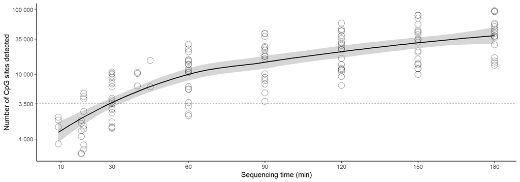

```r
# Script to produce Figures 1c and 1d

setwd("./data/")

library(ggsci)
library(dplyr)

Seq_stats <- read.csv("SeqStats.csv", header = T)


############## CpGs vs Time ########################

library(ggplot2)
library(scales)
P1 <- ggplot(Seq_stats, aes(x = Minutes, y = CpG_sites))

P2 <- P1 + geom_smooth(mapping = aes(linetype = "r1"),
                       method = "loess",
                       formula = y ~ x,
                       se = TRUE,
                       color = "black",
                       show.legend = F)


Q1 <- P2 + geom_point(size=6, shape = 1) +
  theme_classic(base_size=15) +
  scale_x_continuous(name="Sequencing time (min)", breaks = c(10,30,60,90,120,150,180)) +
  geom_hline(yintercept = 3500, linetype="dashed") +
  scale_y_log10(name="Number of CpG sites detected", label = number, breaks = c(1000,3500,10000,35000,100000))
 Q1
```

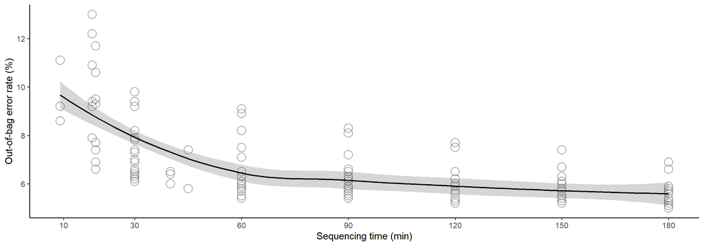

```r
###########################################

################# Time verus Subclassifier Error rate #################

 P5 <- ggplot(Seq_stats, aes(x = Minutes, y = Subclass.OOB.error))

 P6 <- P5 + geom_smooth(mapping = aes(linetype = "r1"),
                        method = "loess",
                        formula = y ~ x,
                        se = TRUE,
                        color = "black",
                        show.legend = F)

 Q3 <- P6 + geom_point(size=6, shape = 1) +

   theme_classic(base_size=15) +
   scale_fill_gradientn(colors=blues9,name="Sequencing\ntime (min)") +
   scale_x_continuous(name="Sequencing time (min)", breaks = c(10,30,60,90,120,150,180)) +
   scale_y_continuous(name="Out-of-bag error rate (%)")

 Q3
```

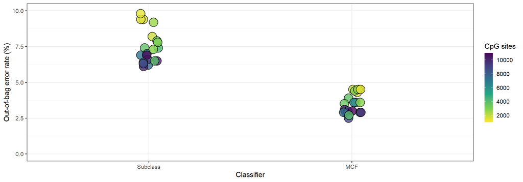

```r
#######################################
library(tidyr)
MCF_Seq_stats <- Seq_stats %>% filter(Minutes==30) %>% select(Patient, CpG_sites, Subclass.OOB.error, MCF.OOB.error) %>%
                               gather("MCF.OOB.error", "Subclass.OOB.error", key = "Classifier", value = "OOB_Error")

############# MCF versus subclass error #####
p7 <- ggplot(MCF_Seq_stats, aes(x=reorder(Classifier,-OOB_Error), y = OOB_Error, fill = CpG_sites))

Q6 <- p7 +
  geom_jitter(size=8, width = 0.05, height = 0, alpha = 0.8, shape = 21, stroke = 1)+
  scale_fill_viridis_c(direction = -1,limits = c(1000, 11000), breaks = c(2000, 4000, 6000, 8000, 10000)) +
  scale_y_continuous(limits = c(0,10), name="Out-of-bag error rate (%)")+
  #theme(legend.position=c(.80, .25))+
  theme(legend.title = element_text(colour="black", size=16, face="bold"))+
  guides(fill = guide_colourbar(barheight = 10))+
  labs(fill = "CpG sites")+
  scale_x_discrete(name="Classifier", labels = c("Subclass","MCF")) +
  theme_bw(15)
Q6
```

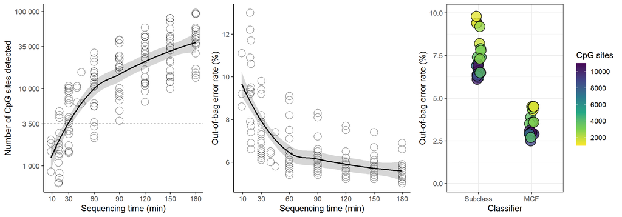

```r
########################
library(gridExtra)
grid.arrange(Q1,  Q3, Q6, nrow = 1)
```

Figure 1C: Dot plots demonstrating the relationship between sequencing time and total CpG sites detected (left panel) and between ad hoc random forest out-of-bag (OOB) error rate and sequencing time using the subgroup classifier (right panel). Dotted line demarks 3500 CpG cut-off for analysis, black line demarks polynomial regression with 95% CI.

Figure 1D: Comparison of random forest OOB error using the methylation class family (MCF) classifier or full subclassification after 30 minutes of nanopore sequencing. Color indicates the number of CpG sites.

### Figure 2E

```r
# To produce Sankey plot of surgical impact, Figure 2e

setwd("./data/")

DF <- as_tibble(read.csv("SeqStats.csv", header = T))

library(tidyr)
library(dplyr)

DF2 <- DF %>% filter(Minutes==30) %>%
            select(Patient,Nanopore_Capper,Simp_Patho_diagnosis,Conclusive,Potential.intraoperative.consequence) %>%
            distinct()

DF2 <- filter(DF2,Patient != "NDMA_105") # This sample does not contain any info on intraop frozen section. Discard from plot

#Reorder columns for plotting
DF3 <- DF2[,c(3,2,4,5)]

DF3$Conclusive <- gsub("Yes", "Conclusive", DF3$Conclusive)
DF3$Conclusive <- gsub("No", "Inconclusive", DF3$Conclusive)

# For some reason the coloring fails if there is a space in the name
DF3$Simp_Patho_diagnosis <- gsub(" ", "_", DF3$Simp_Patho_diagnosis)

links <- DF3 %>% unite(First_key, Simp_Patho_diagnosis, Nanopore_Capper, sep="->", remove = F) %>%
  unite(Second_key, Nanopore_Capper, Conclusive,   sep="->", remove = F) %>%
  unite(Third_key, Conclusive, Potential.intraoperative.consequence,sep="->", remove = F) %>%
  select_(1,3,5) %>%
  gather(Keys, Potential.intraoperative.consequence) %>%
  select_(2) %>% group_by(Potential.intraoperative.consequence) %>% tally(sort = TRUE) %>%
  separate(Potential.intraoperative.consequence, c("Source","Target"), sep="->")

#change the column names to match the Sankey inbut
colnames(links)<-c("Source", "Target", "value")

nodes <- data.frame(
  name=c(as.character(links$Source),
         as.character(links$Target)) %>% unique()
)

# With networkD3, connection must be provided using id, not using real name like in the links dataframe. Reformat it.
links$IDsource <- match(links$Source, nodes$name)-1
links$IDtarget <- match(links$Target, nodes$name)-1

# Load the color map from Capper et al
Colormap <- read.csv("ColorMapFull.csv", header = T)
colnames(Colormap)<-c("name", "colorCode")
Colormap$name <- gsub(" ", "_", Colormap$name)

FindColors <- left_join(nodes, Colormap, by = "name")

color_scale <- data.frame(
  range = FindColors$colorCode,
  domain = FindColors$name,
  nodes = nodes,
  stringsAsFactors = FALSE
)

library(networkD3)
# Make the network
p <- sankeyNetwork(Links = links, Nodes = nodes,
                   Source = "IDsource", Target = "IDtarget",
                   Value = "value",
                   NodeID = "name",
                   fontSize = 15,
                   fontFamily = "sans-serif",
                   nodeWidth = 15,
                   nodePadding = 15,
                   sinksRight=T,
                   margin = c(top=50,right=0, left=0,bottom=50),
                   iterations = 100,
                   colourScale = JS(
                     sprintf(
                       'd3.scaleOrdinal()
  .domain(%s)
  .range(%s)
',
                       jsonlite::toJSON(color_scale$domain),
                       jsonlite::toJSON(color_scale$range)
                     )
                   )
)
#p

library(htmlwidgets)

onRender(
  p,
  '
  function(el, x) {
    d3.selectAll(".node text").attr("text-anchor", "begin").attr("x", 20);
  }
  '
)
```

[interactive chart not shown]

Figure 2E: Sankey plot demonstrating the final neuropathological diagnosis (left), the intraoperative NDMA analysis (for abbreviations see Extended data), the result from intraoperative frozen section pathology and whether improved intraoperative diagnostic classification would have impacted surgical decision-making.

### Extended Figure 1

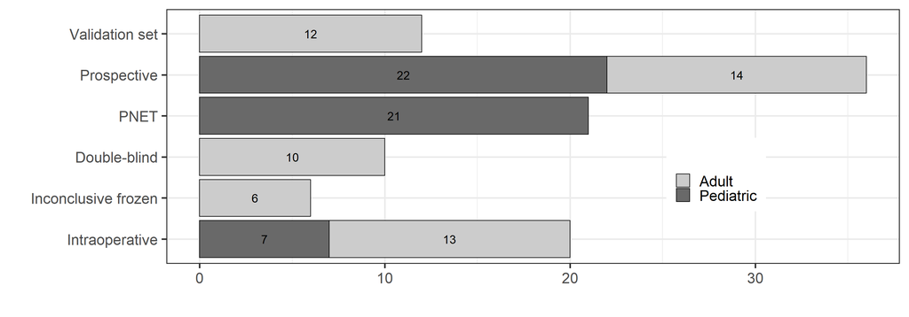

```r
# This script is to generate figure 1a

# Data is imported and turned into a tibble so all dplyr functions function properly

setwd("./data/") # set working directory to where FULL_Nanopore_Final.csv is located

library(dplyr)
FULL <- read.csv("FULL_Nanopore_FINAL.csv", header=T) # 105 patients
FULL <- as_tibble(FULL)

P <- FULL %>% group_by(Category, Cohort) %>% tally() # summarize groups

# Change the names so that they make more sense
P$Category <- gsub("Training set", "Validation set", P$Category)
P$Category <- gsub("Double_Blind", "Double-blind", P$Category)
P$Category <- gsub("Difficult cases", "Inconclusive frozen", P$Category)
P$Category <- gsub("Intraop", "Intraoperative", P$Category)

# order the samples correctly in the barplot so they match how they are introduced in the text
P <- P %>%
  mutate(Category = factor(Category, levels=c("Intraoperative","Inconclusive frozen","Double-blind","PNET","Prospective","Validation set")))

# Make the plot
library(ggplot2)
G <- ggplot(P, aes(x=Category, y=n, fill = Cohort, label = n))

G + geom_bar(position="stack", stat="identity", colour="black")+
  theme_bw(base_size = 22)+
  scale_fill_manual(values=c("#cccccc", "#696969"))+
  #xlab("Patient cohort")+
  xlab("")+
  ylab("")+
  labs(fill = "")+
  coord_flip()+
  theme(legend.position=c(.75, .35))+
  geom_text(size = 5, position = position_stack(vjust = 0.5))
```

Extended Figure 1 Overview of patient cohorts presented in the study. Validation set, PNET, double-blind and inconclusive frozen-sections were analyzed retrospectively. Prospective and intraoperative cases were analyzed prospectively.